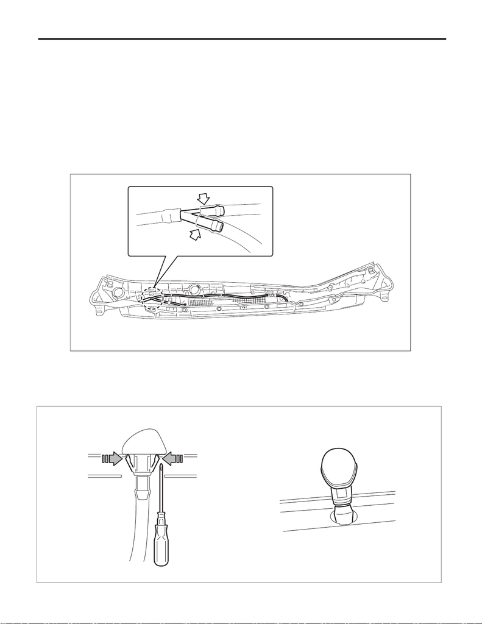

WW-25

Front Washer Nozzle

WIPER AND WASHER SYSTEMS

9. Front Washer Nozzle

A: REMOVAL

1) Disconnect the ground cable from battery. <Ref. to NT-5, BATTERY, NOTE, Note.>

NOTE:

For models other than STI model, disconnect the ground terminal from battery sensor.

2) Remove the arm assembly - windshield wiper. <Ref. to WW-19, REMOVAL, Front Wiper Arm.>

3) Remove the cowl panel - side and the cowl panel assembly. <Ref. to EI-45, REMOVAL, Cowl Panel.>

CAUTION:

Before removing the cowl panel, use an air blower and nylon brush to sweep gravel from the lower

area of the front side of the glass.

4) Disconnect the hose - windshield washer.

5) Remove the nozzle - windshield washer.

(1) Push the claw using a flat tip screwdriver, etc.

(2) When the nozzle - windshield washer lifts up, pull out the nozzle - windshield washer using a clip re-

mover, etc.

(3) Disconnect the hose - windshield washer, and remove the nozzle - windshield washer.

WW-00835

WW-00851

[figure not shown]

Front Washer Nozzle

WIPER AND WASHER SYSTEMS

B: INSTALLATION

CAUTION:

Before installing the windshield glass and the cowl panel, make sure there is no gravel in the install-

ing area.

1) Install the nozzle - windshield washer.

(1) Install the nozzle - windshield washer.

(2) Install the hose - windshield washer.

2) Install the cowl panel - side and the cowl panel assembly. <Ref. to EI-46, INSTALLATION, Cowl Panel.>

3) Install the arm assembly - windshield wiper. <Ref. to WW-19, INSTALLATION, Front Wiper Arm.>

4) Connect the battery ground terminal. <Ref. to NT-5, BATTERY, NOTE, Note.>

NOTE:

For models other than STI model, connect the ground terminal to battery sensor.

5) Adjust the position of the nozzle - windshield washer. <Ref. to WW-27, ADJUSTMENT, Front Washer

Nozzle.>

C: INSPECTION

• Make sure the nozzle - windshield washer and the hose - windshield washer are not clogged.

• Make sure the hose - windshield washer is not bent.

• Check the position of the nozzle - windshield washer. <Ref. to WW-27, ADJUSTMENT, Front Washer Noz-

zle.>

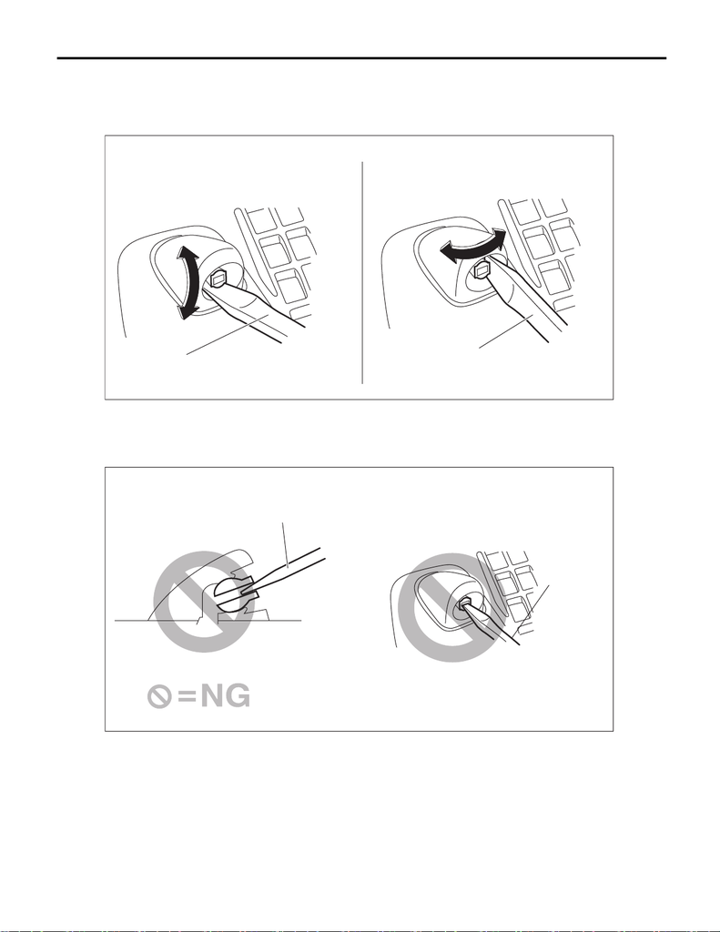

WW-27

Front Washer Nozzle

WIPER AND WASHER SYSTEMS

D: ADJUSTMENT

1) Turn the wiper switch to OFF position.

2) While the vehicle is at a standstill, insert a precision screwdriver (A) or equivalent into the clearance on the

upper/lower side or the right/left side of the nozzle - windshield washer to perform necessary adjustment.

CAUTION:

The nozzle - windshield washer is made of resin. If precision screwdriver (A) or equivalent is inserted

into discharge port for adjustment, the discharge port can be deformed, and washer fluid cannot be

sprayed.

(A)

(A)

WW-01094

(A)

(A)

WW-01095

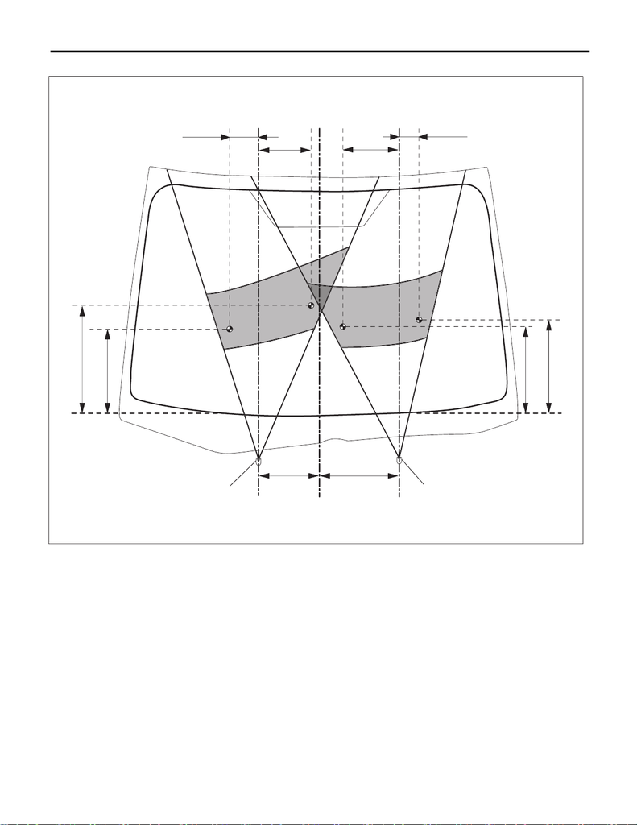

Front Washer Nozzle

WIPER AND WASHER SYSTEMS

3) Adjust the washer injection position as shown in the figure.

(A) Nozzle - windshield washer (B) Ceramic line

WW-01096

(B) (B)

215 mm

(8.46 in)

285 mm

(11.22 in)

(A)

294 mm

(11.57 in)

374 mm

(14.72 in)

(A)

298 mm

(11.73 in)

323 mm

(12.72 in)

69 mm

(2.72 in)

103 mm

(4.06 in)

180 mm

(7.09 in)

197 mm

(7.76 in)

[figure not shown]

ENTERTAINMENT

ET

Page

2. Relay and Fuse ..........................................................................................3

3. Audio System .............................................................................................4

4. Navigation System .....................................................................................5

5. Audio ..........................................................................................................8

6. Front Speaker ............................................................................................9

7. Rear Speaker ...........................................................................................11

8. Woofer ......................................................................................................12

9. Power Amplifier ........................................................................................13

10. Antenna ....................................................................................................14

11. Steering Satellite Switch ..........................................................................16

12. Microphone ..............................................................................................18

13. Navigation Body .......................................................................................19

14. GPS Antenna ...........................................................................................20

15. Rearview Camera System .......................................................................21

16. Front Accessory Power Supply Socket ....................................................23

17. Rear Accessory Power Supply Socket .....................................................25

18. AUX Input Terminal ..................................................................................26